NB-FOXR2 project [[source](https://github.com/fungenomics/NB-FOXR2)]

# 09 - FOXR2 CUT&RUN in FOXR2 p53LOF mouse models

Bhavyaa Chandarana [bhavyaa.chandarana@mail.mcgill.ca] and Steven Hébert [steven.hebert@ladydavis.ca]

05 November, 2024

# 1 Configuration

Configuration of project directory & analysis outputs:

**Show full config**

```r
source(here("rr_helpers.R"))

# Set up outputs
message("Document index: ", doc_id)
```

```
## Document index: 09
```

```r
# Specify where to save outputs
out        <- here("output", doc_id); dir.create(out, recursive = TRUE)
figout     <- here("figures", doc_id, "/")
cache      <- paste0("/project/kleinman/bhavyaa.chandarana/cache/NB-FOXR2/public/", doc_id, "/")
```

The root directory of this project is:

```
## /project/kleinman/bhavyaa.chandarana/from_hydra/2023-05-NB-FOXR2/public
```

Outputs and figures will be saved at these paths, relative to project root:

```
## public/output/09
```

```
## public/figures/09//
```

Setting a random seed:

```r
set.seed(100)
```

# 2 Overview

Note that throughout the code we refer to the CUT&RUN data as "ChIP" due to its similarity in the analysis stage.

# 3 Libraries

```r
library(here)
library(magrittr)
library(tidyr)
library(dplyr)
library(readr)
library(readxl)
library(stringr)
library(glue)
library(purrr)
library(ggplot2)
library(cowplot)
library(ComplexHeatmap)
library(GenomeInfoDb)
library(GenomicRanges)
library(GenomicFeatures)
library(rtracklayer)
library(Seurat)
library(Signac)
library(gprofiler2)
library(VennDiagram)

source(here("include/style.R"))
source(here("code/functions/scRNAseq.R"))
source(here("code/functions/RNAseq.R"))

ggplot2::theme_set(theme_min())
```

# 4 Load data

FOXR2-V5 CUT&RUN (similar to ChIP) was run with two protocols "native" and "X-link", with n=2 replicates each.

A FOXR2-V5 experiment was also run in a cell line lacking V5-tagged insertion (n=2 replicates). We also load it here to use as a control.

```r
chip_path <- here("data/ChIPseq/pipeline_genpipes/peaks")

# X-link FOXR2 peaks
rep1_FOXR2_peaks <- rtracklayer::import(glue("{chip_path}/AN24377_FOXR2_P53LOF_1_X-link_JAB1979A5-1.V5_peaks.narrowPeak"), format = "narrowPeak")
rep2_FOXR2_peaks <- rtracklayer::import(glue("{chip_path}/AN24377_FOXR2_P53LOF_2_X-link_JAB1979A5-2.V5_peaks.narrowPeak"), format = "narrowPeak")

# X-link V5 peaks
rep1_V5_peaks <- rtracklayer::import(glue("{chip_path}/AH25351_G34R_1_X-link_JAB1979A5-3.V5_peaks.narrowPeak"), format = "narrowPeak")
rep2_V5_peaks <- rtracklayer::import(glue("{chip_path}/AH25351_G34R_2_X-link_JAB1979A5-4.V5_peaks.narrowPeak"), format = "narrowPeak")

# Create lists of peaks
chip_foxr2_peak_list <- list(rep1_FOXR2 = rep1_FOXR2_peaks,
               rep2_FOXR2 = rep2_FOXR2_peaks)

chip_V5_peak_list <- list(rep1_V5 = rep1_V5_peaks,
               rep2_V5 = rep2_V5_peaks)

# Remove non-standard chromosomes/contigs from each sample
standard_chrom_mm <- function(gr) {
    gr <- gr[GenomicRanges::seqnames(gr) %in% c(1:19, 'X', 'Y')]
    GenomeInfoDb::seqlevels(gr) <- c(1:19, 'X', 'Y')
    return(gr)
}

chip_foxr2_peak_list <- map(chip_foxr2_peak_list, standard_chrom_mm)
chip_V5_peak_list <- map(chip_V5_peak_list, standard_chrom_mm)
```

# 5 Define peaks

## 5.1 Filter V5 peaks

We have control data from FOXR2-V5 CUT&RUN in a cell line lacking V5 insertion. The peaks in this sample arise from binding regions of V5 antibody in the genome. We use this as a background to filter out false positive peaks.

```r
# Concatenate the V5 peaks
all_V5_peaks <- c(chip_V5_peak_list[[1]], chip_V5_peak_list[[2]]) %>%
  sortSeqlevels %>%
  sort %>%
  reduce(min.gapwidth = 0)

# Remove V5 peaks from the FOXR2 peaks
chip_foxr2_peak_list_no_V5 <- chip_foxr2_peak_list
chip_foxr2_peak_list_no_V5[[1]] <- subsetByOverlaps(chip_foxr2_peak_list_no_V5[[1]], all_V5_peaks, invert = T, minoverlap = 10)
chip_foxr2_peak_list_no_V5[[2]] <- subsetByOverlaps(chip_foxr2_peak_list_no_V5[[2]], all_V5_peaks, invert = T, minoverlap = 10)

# Check the length of the peak lists (as a QC)
map(chip_foxr2_peak_list, length)
```

```
## $rep1_FOXR2
## [1] 31861
##
## $rep2_FOXR2
## [1] 38522
```

```r
map(chip_foxr2_peak_list_no_V5, length)
```

```
## $rep1_FOXR2
## [1] 31718
##
## $rep2_FOXR2
## [1] 38393
```

```r
# Create a narrowpeak file for the ChIP-seq FOXR2 samples after removing the V5 peaks
write.table(chip_foxr2_peak_list_no_V5[[1]], file = glue("{out}/rep1_FOXR2_no_V5.narrowpeak"), sep = "\t", quote = F, row.names = F, col.names = T)
write.table(chip_foxr2_peak_list_no_V5[[2]], file = glue("{out}/rep2_FOXR2_no_V5.narrowpeak"), sep = "\t", quote = F, row.names = F, col.names = T)
```

## 5.2 Intersect FOXR2 CUT&RUN & ATAC-seq peaks

We expect high-quality FOXR2 CUT&RUN peaks to overlap with open chromatin (ATAC-seq peaks) derived from scMultiome of the same mouse model.

Here, we compute the overlap between these peaks, and use ATAC peaks to filter CUT&RUN peaks. In the end, we retain the intersect of peaks between ATAC-seq, and the two replicates of X-link FOXR2 CUT&RUN.

Define a function to plot triple venn diagram:

```r
# Function to plot triple venn diagram from a list containing 3 GRanges objects
venn_from_gr_list <- function(gr_list, plot_title){

  overlap_all <- Reduce(function(x, y) subsetByOverlaps(x, y, minoverlap = 10), gr_list) %>% length()

  overlap_12 <- findOverlaps(gr_list[[1]], gr_list[[2]], minoverlap = 10)
  overlap_23 <- findOverlaps(gr_list[[2]], gr_list[[3]], minoverlap = 10)
  overlap_13 <- findOverlaps(gr_list[[1]], gr_list[[3]], minoverlap = 10)

  n_overlap_12 <- min(length(unique(queryHits(overlap_12))), length(unique(subjectHits(overlap_12))))
  n_overlap_23 <- min(length(unique(queryHits(overlap_23))), length(unique(subjectHits(overlap_23))))
  n_overlap_13 <- min(length(unique(queryHits(overlap_13))), length(unique(subjectHits(overlap_13))))

  venn.plot = draw.triple.venn(length(gr_list[[1]]),
                 length(gr_list[[2]]),
                 length(gr_list[[3]]),
                 n_overlap_12,
                 n_overlap_23,
                 n_overlap_13,
                 overlap_all,
                 category = c("rep1_FOXR2", "rep2_FOXR2", "ATAC"),
                 euler.d = T,
                 scaled = T,
                 fill = c("#33CC00", "#33CC00", "#009999"))

  grid.draw(venn.plot)
}
```

Load ATAC peaks:

```r
# Load ATAC peaks produced from multiome processing pipeline
Foxr2_p53_r1_ATAC_peaks <- rtracklayer::import(here("data/singlecell/pipeline_scMultiome_mm/AN24377/ATAC/macs2.peaks.standard.blacklistremoved.narrowpeak"), format = "narrowPeak")

# Note that the blacklisted peaks were removed from list of peaks
# The list of blacklisted peaks comes from this set (from Signac package)
write.table(Signac::blacklist_mm10, file = glue("{out}/blacklist_mm10.tsv"),
            sep = "\t", quote = F, row.names = F, col.names = F)

# Modify the blacklist_mm10 file to get a sorted bed files with names
system(glue("sort -Vk1,1 -k2,2 -k3,3 {out}/blacklist_mm10.tsv |
               cut -f1-3,6 |
               sed 's/ /_/g' > {out}/blacklist_mm10.bed"))

# Remove non-standard chromosomes
Foxr2_p53_r1_ATAC_peaks <- standard_chrom_mm(Foxr2_p53_r1_ATAC_peaks)
```

Plot number of peaks overlapping between CUT&RUN replicates and ATAC without any filtering:

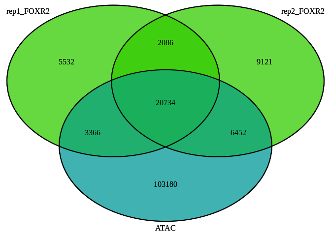

```r
peak_list <- c(chip_foxr2_peak_list_no_V5, FOXR2_ATAC = Foxr2_p53_r1_ATAC_peaks)
venn_from_gr_list(peak_list, "venn_ChIP_ATAC_nofilter")
```

Filter CUT&RUN and ATAC peaks by quality metrics:

```r
# Add width column to the peaks
chip_foxr2_peak_list_no_V5 <- map(chip_foxr2_peak_list_no_V5, ~ {
  .x$width <- width(.x)
  return(.x)
})

Foxr2_p53_r1_ATAC_peaks$width <- width(Foxr2_p53_r1_ATAC_peaks)

# Filter peaks of ChIP-seq and ATAC-seq
# Peaks from ChIP-seq and ATAC-seq have different value distribution
# (signalValue, qValue), so different thresholds need to be used.
filtered_2_chip_foxr2_peak_list_no_V5 <- map(chip_foxr2_peak_list_no_V5,
        ~ .x[which(.x$qValue > 6 & .x$signalValue > 6 & .x$width < 10000),])
filtered_2_Foxr2_p53_r1_ATAC_peaks <- Foxr2_p53_r1_ATAC_peaks[Foxr2_p53_r1_ATAC_peaks$qValue > 4 &
                                                            Foxr2_p53_r1_ATAC_peaks$signalValue > 2 &
                                                            Foxr2_p53_r1_ATAC_peaks$width < 10000,]
```

Plot number of peaks overlapping between CUT&RUN replicates and ATAC after filtering.

This plot was adapted in Adobe Illustrator for the publication.

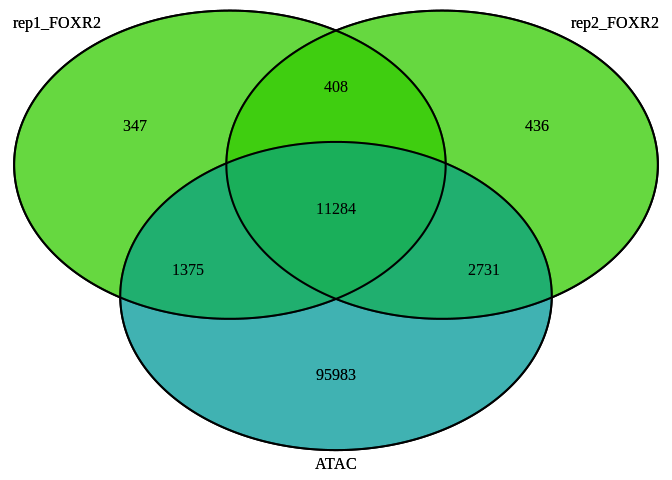

```r
### Check number of peaks overlapping
filtered_2_peak_list <- c(filtered_2_chip_foxr2_peak_list_no_V5, FOXR2_ATAC = filtered_2_Foxr2_p53_r1_ATAC_peaks)
venn_from_gr_list(filtered_2_peak_list, "venn_ChIP_ATAC_filtered_stringent")
```

```r
# export the peaks into bed files
imap(filtered_2_peak_list[1:2], ~export.bed(.x,
                                     con=glue("{out}/{.y}_qVal6_FC6_width10k.bed"),
                                     format = "bed"))
```

```
## $rep1_FOXR2
## BEDFile object
## resource: /project/kleinman/bhavyaa.chandarana/from_hydra/2023-05-NB-FOXR2/public/output/09/rep1_FOXR2_qVal6_FC6_width10k.bed
##
## $rep2_FOXR2
## BEDFile object
## resource: /project/kleinman/bhavyaa.chandarana/from_hydra/2023-05-NB-FOXR2/public/output/09/rep2_FOXR2_qVal6_FC6_width10k.bed
```

```r
export.bed(filtered_2_peak_list[[3]],
         con=glue("{out}/FOXR2_ATAC_qVal4_FC2_width10k.bed"),
         format = "bed")
```

Get a bed file with intersecting peaks between the n=2 FOXR2 CUT&RUN and ATAC, for IGV:

```r
# Create a bed file of the overlap between the 3 sets of peaks (ChIP FOXR2 rep 1&2, ATAC FOXR2-p53 rep1)
overlap_all <- Reduce(function(x, y) subsetByOverlaps(x, y, minoverlap = 10), filtered_2_peak_list)
export.bed(overlap_all, con = glue("{out}/intersect_ChIP_ATAC_qVal6_FC6_width10k.bed"), format = "bed")

# Create the intersect with the exact bases that intersect the ChIP FOXR2 rep 1&2 and ATAC FOXR2-p53 rep1
# Run after: module load bedtools/2.30.0
system(glue("intersectBed -a {out}/rep1_FOXR2_qVal6_FC6_width10k.bed -b {out}/rep2_FOXR2_qVal6_FC6_width10k.bed > {out}/exact_ChIP-intersect_qVal6_FC6_width10k.bed"))
system(glue("intersectBed -a {out}/exact_ChIP-intersect_qVal6_FC6_width10k.bed -b {out}/FOXR2_ATAC_qVal4_FC2_width10k.bed > {out}/exact_intersect_ChIP_ATAC_qVal6_FC6_width10k.bed"))
```

## 5.3 Peak QC metric distribution

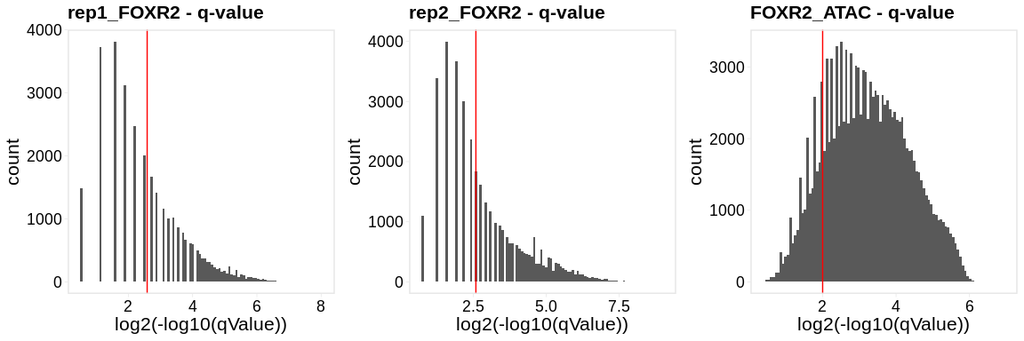

```r
qval_threshold <- c(6, 6, 4)
fold_threshold <- c(6, 6, 2)
width_threshold1 <- 1
width_threshold2 <- 10000

# Q values
# log-log scale
map2(names(peak_list), qval_threshold,
     ~ data.frame(num = peak_list[[.x]]$name,
                  qValue = peak_list[[.x]]$qValue) %>%
            ggplot(aes(x = log2(qValue))) +
            geom_histogram(bins = 100) +
            xlab("log2(-log10(qValue))") +
            ggtitle(glue("{.x} - q-value")) +
            geom_vline(xintercept = log2(.y), color = "red"))  %>%
    cowplot::plot_grid(plotlist = ., ncol = 3)
```

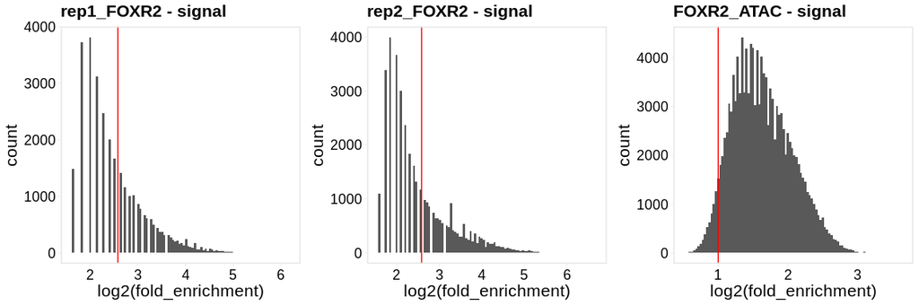

```r
# Fold enrichment
map2(names(peak_list), fold_threshold,
     ~ data.frame(num = peak_list[[.x]]$name,
                  fold_enrichment = peak_list[[.x]]$signalValue) %>%
            ggplot(aes(x = log2(fold_enrichment))) +
            geom_histogram(bins = 100) +
            xlab("log2(fold_enrichment)") +
            ggtitle(glue("{.x} - signal")) +
            geom_vline(xintercept = log2(.y), color = "red")) %>%
    cowplot::plot_grid(plotlist = ., ncol = 3)
```

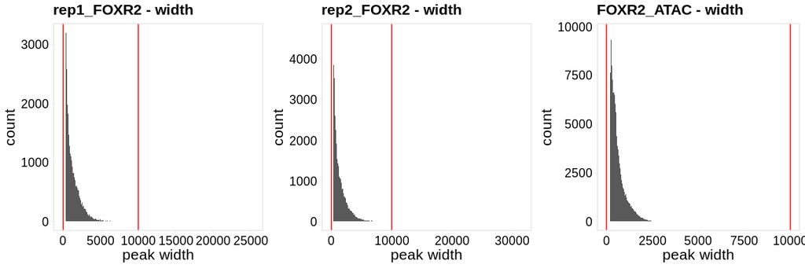

```r
# Peak width

width_df <- function(gr){

    df <- data.frame(num = gr$name)
    df$width <- width(gr)
    return(df)

}

imap(peak_list,
     ~ width_df(.x) %>%
            ggplot(aes(x = width)) +
            geom_histogram(bins = 300) +
            xlab("peak width") +
            ggtitle(glue("{.y} - width")) +
            geom_vline(xintercept = width_threshold1, color = "red") +
            geom_vline(xintercept = width_threshold2, color = "red"))  %>%
    cowplot::plot_grid(plotlist = ., ncol = 3)
```

# 6 Motif analysis

Motif analysis with HOMER was conducted with scripts in the following directory:

```
code/scripts/ChIP
```

Originally written and run by Steven Hébert.

```r
# Load Homer motif results
motifs <- read_tsv(glue("{out}/motifs_size100_100/knownResults.txt"))
# Adjust p-values and count the number of significant motifs
motifs_adj <- motifs %>%
  mutate(padj_BH = p.adjust(`P-value`, method = "BH"))
nrow(filter(motifs_adj, padj_BH < 0.05))
```

```
## [1] 193
```

Plot the top motifs and their -log10 adjusted p-value, coloring by the motif type (ETS, SOX, other):

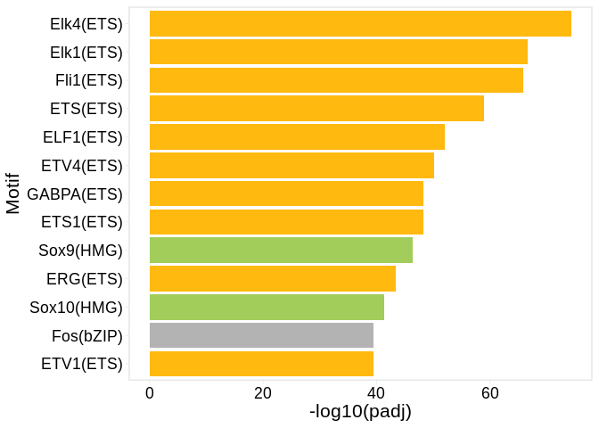

```r
motifs_gg <- motifs %>%
  mutate(padj_BH = p.adjust(`P-value`, method = "BH")) %>%
  slice_max(order_by = -`Log P-value`, n = 13, with_ties = T) %>%
  mutate(Motif_name = str_split(`Motif Name`, "/", simplify = T)[,1]) %>%
  mutate(Motif_group = case_when(grepl(.$Motif_name, pattern = "ETS") ~ "ETS",
                                 grepl(.$Motif_name, pattern = "Sox") ~ "SOX",
                                 TRUE                                        ~ "Other"))

motifs_gg %>%
  ggplot(aes(x = -log10(padj_BH), y = reorder(Motif_name, -padj_BH))) +
  geom_bar(stat = "identity", aes(fill = Motif_group)) +
  ylab("Motif") +
  xlab("-log10(padj)") +
  scale_fill_manual(values = c("ETS" = "darkgoldenrod1",
                               "SOX" = "darkolivegreen3",
                               "Other" = "grey70")) +
  theme(legend.position = "none")
```

Reorder the bars to group the motif types together, and rank by adjusted p-value within each of the groups. This is the final plot used in the publication.

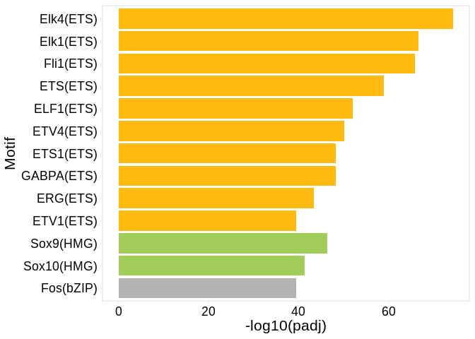

```r
df <- motifs_gg %>%
    arrange(padj_BH) %>%
    dplyr::select(Motif_name, Motif_group)

order <- c(df %>% filter(Motif_group == "ETS") %>% .$Motif_name,
           df %>% filter(Motif_group == "SOX") %>% .$Motif_name,
           df %>% filter(Motif_group == "Other") %>% .$Motif_name)

motifs_gg %>%
  mutate(Motif_name = factor(Motif_name, levels = rev(order))) %>%
  ggplot(aes(x = -log10(padj_BH), y = Motif_name)) +
  geom_bar(stat = "identity", aes(fill = Motif_group)) +
  ylab("Motif") +
  xlab("-log10(padj)") +
  scale_fill_manual(values = c("ETS" = "darkgoldenrod1",
                               "SOX" = "darkolivegreen3",
                               "Other" = "grey70")) +
  theme(legend.position = "none")
```

# 7 Reproducibility

This document was last rendered on:

```
## 2024-11-05 11:04:56
```

The git repository and last commit:

```
## Local:    main /project/kleinman/bhavyaa.chandarana/from_hydra/2023-05-NB-FOXR2/public
## Remote:   main @ origin (https://github.com/fungenomics/NB-FOXR2.git)
## Head:     [72d1c5c] 2024-11-04: Add DOI badge
```

The random seed was set with `set.seed(100)`

A project of the Kleinman Lab at McGill University, using the [rr](https://github.com/sjessa/rr/) reproducible research template.